# Analysis of Variance (ANOVA)

Sébastien Biass

Earth Sciences, University of Geneva 🇨🇭

Henry Hoult

Earth Sciences, University of Geneva 🇨🇭

Stéphane Guerrier

Earth Sciences & Pharmaceutical Sciences, University of Geneva 🇨🇭

Dominique Couturier

Cancer Research UK, University of Cambridge 🇬🇧

Yuming Zhang

Department of Biostatistics, Harvard University 🇺🇸

## How does it work?

- The data are the outcome of a random process: they form a random sample of a (possibly conceptual) population.
- Statistical inference uses the sample to learn about the population: estimating quantities and testing hypotheses.
- Examples of research questions:
  - pharma: does a new drug lower blood pressure more than the standard of care?
  - earth: do magmas erupting through thick crust have a higher SiO$_2$ content than those erupting through thin crust?

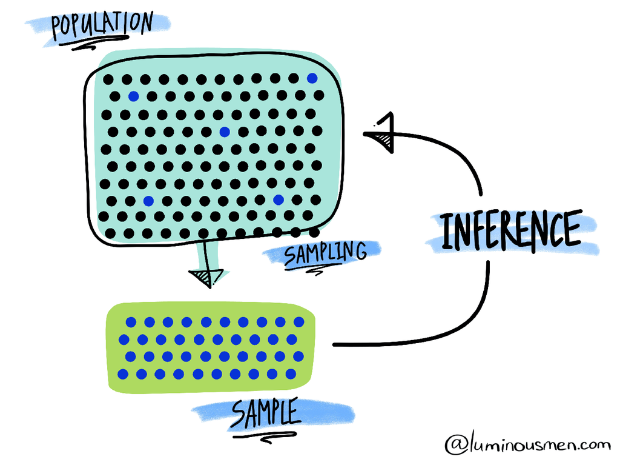

Source: [luminousmen](https://luminousmen.com)

## The big picture: p-hacking

P-hacking is the misuse of data analysis to find patterns that can be presented as statistically significant: run many tests on the data and report only those that come back significant. Example: the number of letters in the [Scripps National Spelling Bee](https://en.wikipedia.org/wiki/Scripps_National_Spelling_Bee) winning word correlates with the number of people killed by venomous spiders in the US.

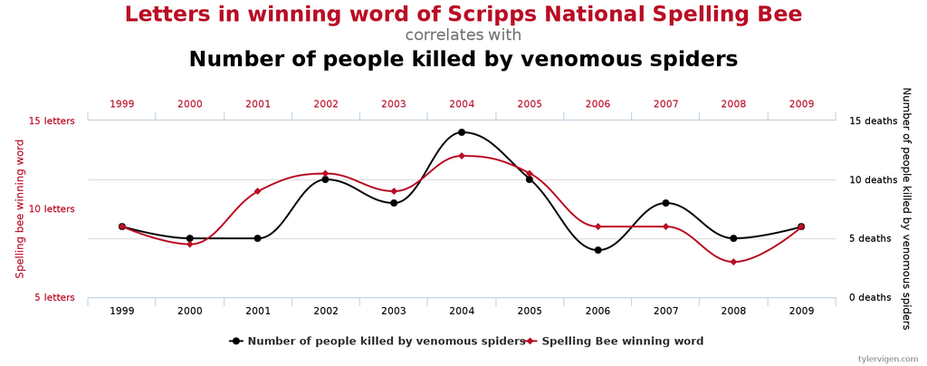

Source: [Wikipedia on data dredging](https://en.wikipedia.org/wiki/Data_dredging). 👋 If you want to know more, take a look [here](https://www.ncbi.nlm.nih.gov/pmc/articles/PMC1124898/).

## How to p-hack? 🤔

Are Republicans good or bad for the US economy? Both!! Choose the terms, the measure of the economy and the years, and you can “prove” either. Try it [here](https://stats.andrewheiss.com/hack-your-way/) (a rebuild of the original FiveThirtyEight tool, archived [here](https://web.archive.org/web/20241222202340/https://projects.fivethirtyeight.com/p-hacking/)).

[figure not shown]

## The garden of forking paths

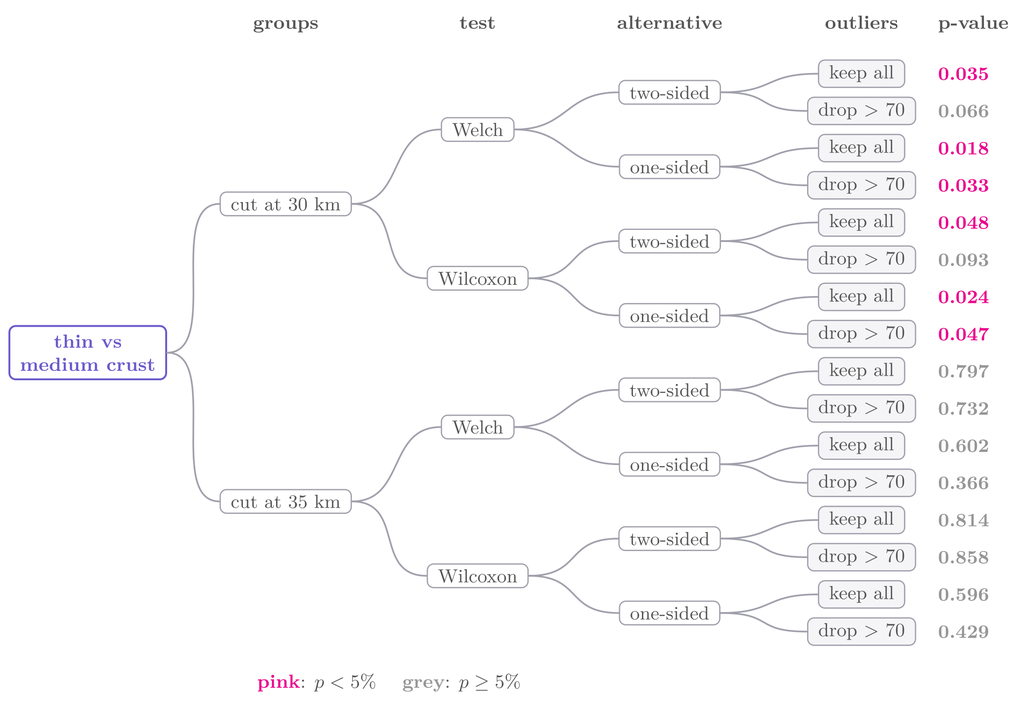

- No fishing needed: every analysis involves choices made after seeing the data (which groups, which test, one- or two-sided, what to do with outliers, …). Each path looks reasonable, and only one is reported.
- The data of this class, 16 defensible analyses: p-values from $1.8\%$ to $86\%$, six of them below $5\%$. The reported p-value ignores the paths not taken.
- Remedies: pre-register the path before looking at the data, or report the whole garden (multiverse analysis).

Gelman, A. & Loken, E. (2014), “The statistical crisis in science”, *American Scientist* 102, 460. In finance: Coqueret, G. (2023), “Forking paths in financial economics”, arXiv:2401.08606.

## This brings us to “HARKing”

HARKing is an acronym coined by Norbert Kerr for the questionable research practice of “Hypothesizing After the Results are Known”: presenting a post hoc hypothesis in the introduction of a research report as if it were an a priori hypothesis.

How to do it? 🤔

- Test 20 jelly bean colours: one of them comes out linked to acne (more on this later).
- Pretend this was our original hypothesis.
- Et voilà!

👋 If you want to know more, have a look [here](https://en.wikipedia.org/wiki/HARKing) and the references therein.

## The costs of HARKing (and p-hacking)

HARKing and p-hacking are (arguably) playing an important role in the replication crisis in science: when 100 published psychology studies were repeated, most p-values and effect sizes did not hold up.

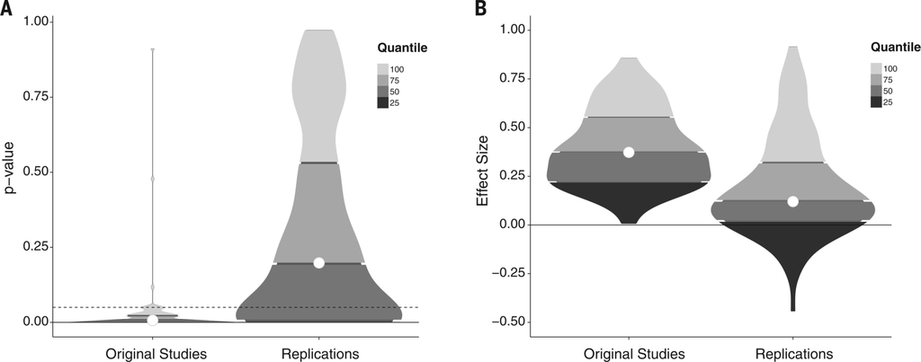

Source: [Open Science Collaboration, “Estimating the reproducibility of psychological science”, *Science* 349 (2015)](https://doi.org/10.1126/science.aac4716). 👋 If you want to know more, take a look [here](https://en.wikipedia.org/wiki/Replication_crisis).

## The cost for society

Contradictory studies (coffee, wine, milk, …) make the public cynical about science: “find the study that sounds best to you and go with that”. Once evidence can be picked like that, it has lost its power.

[figure not shown]

👋 If you want to know more, take a look [here](https://www.youtube.com/watch?v=0Rnq1NpHdmw).

## The four horsemen of irreproducibility

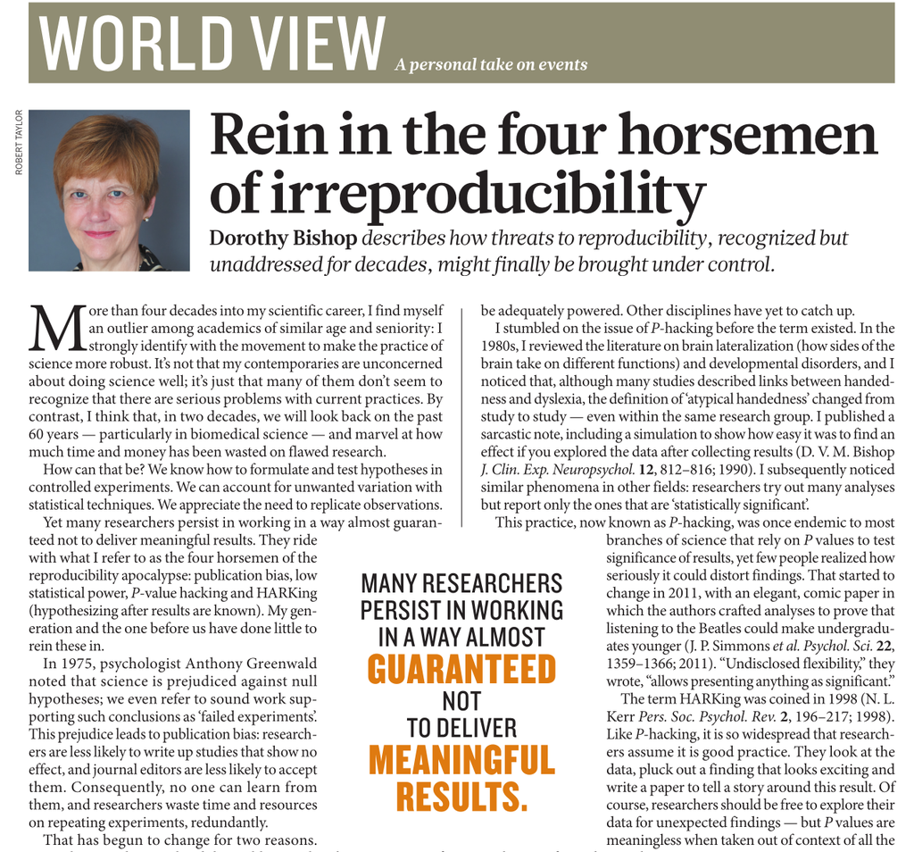

Dorothy Bishop’s four horsemen of the reproducibility apocalypse:

- publication bias
- low statistical power
- p-hacking
- HARKing

We will meet the last three today. The remedies she lists are now standard: pre-registration, registered reports, open data and code.

Source: [D. V. M. Bishop, *Nature* 568, 435 (2019)](https://www.nature.com/articles/d41586-019-01307-2).

## Case study

[figure not shown]

Hypothesis: thicker crust above subduction zones should produce lavas with higher silica (SiO$_2$) content.

👋 Farner, M.J. & Lee, C.-T.A. (2017). *Earth and Planetary Science Letters*, 470, 96–107. [doi:10.1016/j.epsl.2017.04.025](https://doi.org/10.1016/j.epsl.2017.04.025)

## Case study — why would it be so?

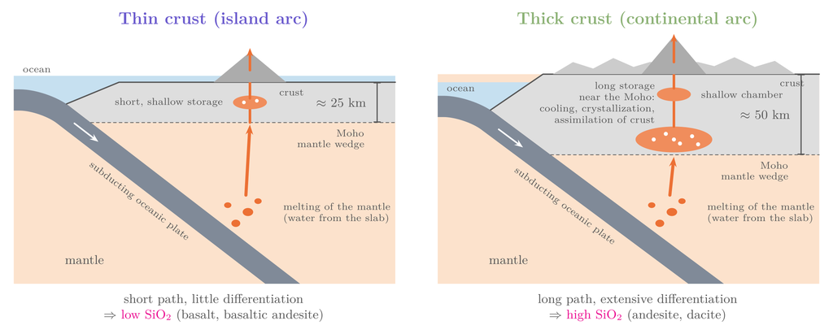

- Under thick crust, rising magmas travel further and are stored longer at depth: they cool, crystallize (and assimilate crust) more, so the erupted magma is more differentiated, i.e. richer in SiO$_2$.
- Scientific hypothesis: magmas erupting through thick crust have a higher SiO$_2$ content than those erupting through thin crust.
- Question for this class: is this visible in the data, and how sure can we be of what we see?

## Case study — a global study

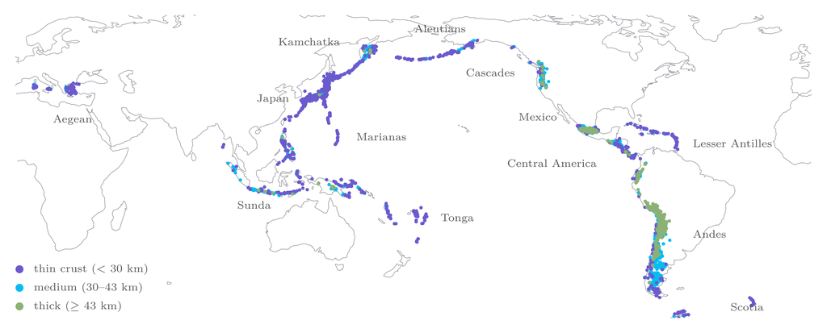

- Compare magma geochemistry of samples from multiple locations: 26 arcs, 8498 cells of $10 \times 10$ km (colours: crustal-thickness class, next slide).
- Data sourced from [GEOROC](https://georoc.eu/georoc/new-query2.asp), the public online geochemistry database.

## Case study — defining the groups

- Sample elevation used as a proxy for crustal thickness.
- Continuous variable (elevation, m a.s.l.) broken into discrete groups.
- Major-element concentrations can be compared between each group to test for statistically significant differences.
- E.g. SiO$_2$, MgO, FeO, CaO.
- In this class: three crustal-thickness groups, thin $< 30$ km, medium $30$–$43$ km, thick $\geq 43$ km, and SiO$_2$.

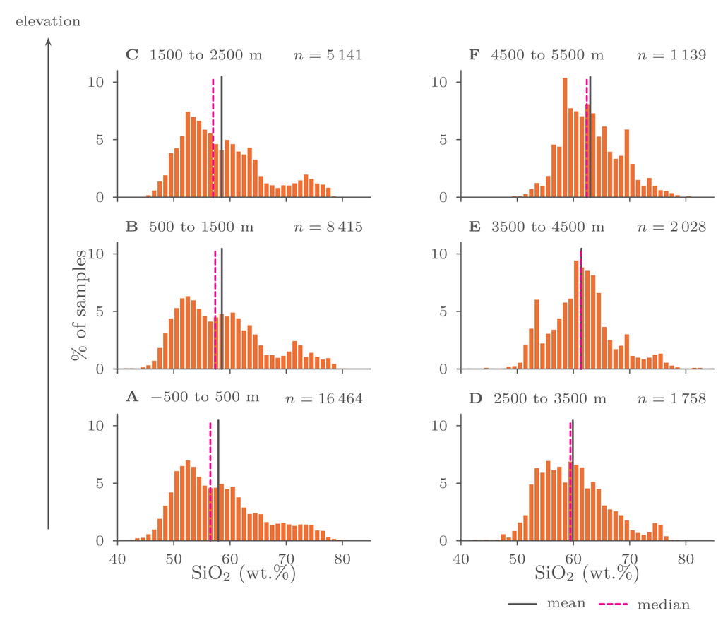

SiO$_2$ by elevation bin: Fig. 2 of Farner & Lee (2017), redrawn from their data.

## Case study — the data

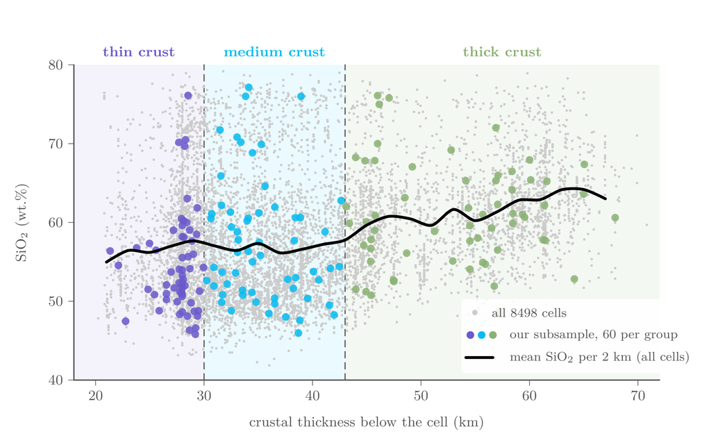

- Each point is a cell. The mean SiO$_2$ per 2 km of thickness (black line) rises from about 56 to 63 wt.%: the trend is there, but so is a huge scatter.
- We work with one random subsample of 60 cells per group (coloured points; fixed seed), the size of a typical field study. The full dataset is on GitHub.

## Case study — a first look

| Group | $n$ | mean | sd | median |
| --- | --- | --- | --- | --- |
| thin | 60 | 54.6 | 6.2 | 53.0 |
| medium | 60 | 57.3 | 7.7 | 55.4 |
| thick | 60 | 61.0 | 6.4 | 60.6 |

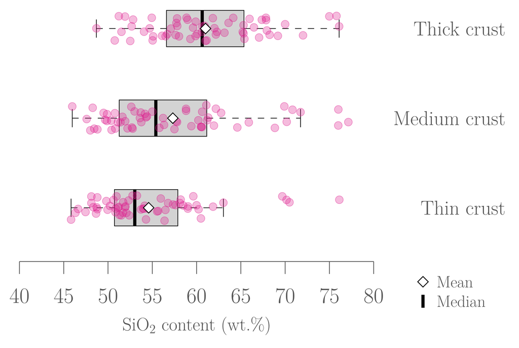

## Hypothesis testing

- A scientific hypothesis is translated into two mutually exclusive statistical hypotheses:

$$H_0: \theta\hspace{0.1cm} {\color{#eb078e}{\in}}\hspace{0.1cm}\Theta_0 \quad \text{and} \quad H_a: \theta\hspace{0.1cm} {\color{#eb078e}{\not\in}}\hspace{0.1cm}\Theta_0$$

- Null hypothesis $\color{#373895}{H_0}$: the statement being tested; the test weighs the evidence against it.
- Alternative hypothesis $\color{#373895}{H_a}$: what we suspect (or hope) to be true instead.

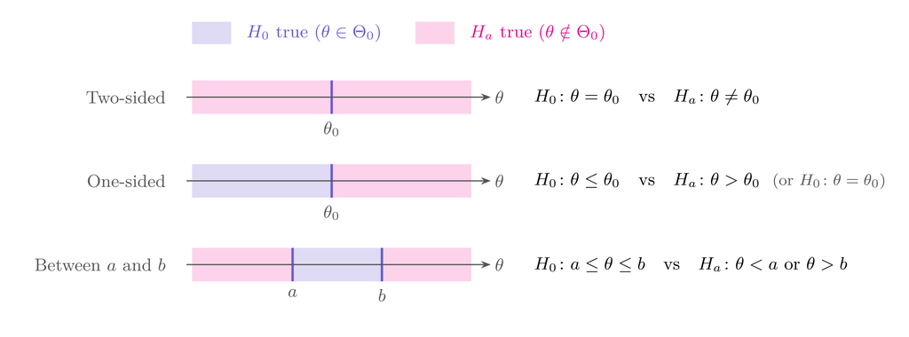

## Hypothesis testing

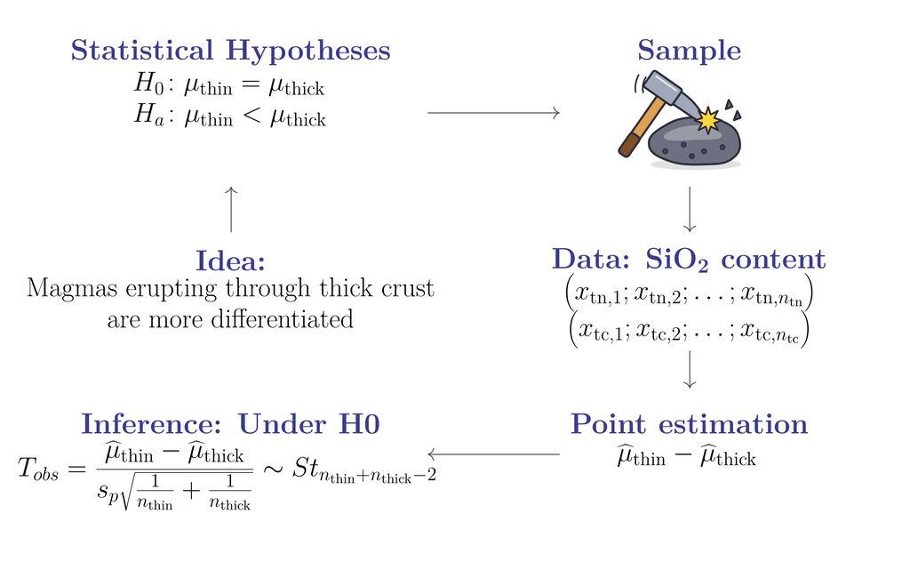

## Standard procedure

1. Hypotheses: state $H_0$ and $H_a$ from the research question.
2. Significance level: choose $\alpha$, the probability of rejecting $H_0$ when it is true (typically $5\%$), *before* looking at the results.
3. p-value: choose a suitable test (look at the data) and compute its p-value, the probability, if $H_0$ were true, of a result at least as extreme as the one observed (⚠️ it is **not** the probability that $H_0$ is true).
4. Decision:
   - $\text{p-value} < \alpha$: reject $H_0$ and accept $H_a$, the result is significant.
   - $\text{p-value} \geq \alpha$: do not reject $H_0$, nothing can be concluded (“absence of evidence is not evidence of absence”).

| **Decision** | $H_0$ is true | $H_0$ is false |
| --- | --- | --- |
| Don’t reject $H_0$ | ✅ correct (prob $1-\alpha$) | ⚠️ Type II error (prob $\beta$) |
| Reject $H_0$ | ⚠️ Type I error (prob $\alpha$) | ✅ correct (prob $1-\beta$, the power) |

## How to understand p-values?

[figure not shown]

👋 If you want to know more have a look [here](https://xkcd.com/1478/).

## P-values may be controversial

P-values have been misused many times because understanding what they mean is not intuitive!

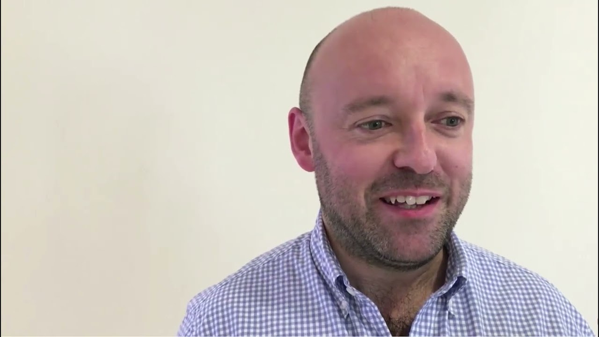

▶

▶ Click to watch the video *p-value* on YouTube (opens in a new tab).

👋 If you want to know more have a look [here](https://fivethirtyeight.com/features/statisticians-found-one-thing-they-can-agree-on-its-time-to-stop-misusing-p-values/).

## Student’s $t$-test: a brewery story

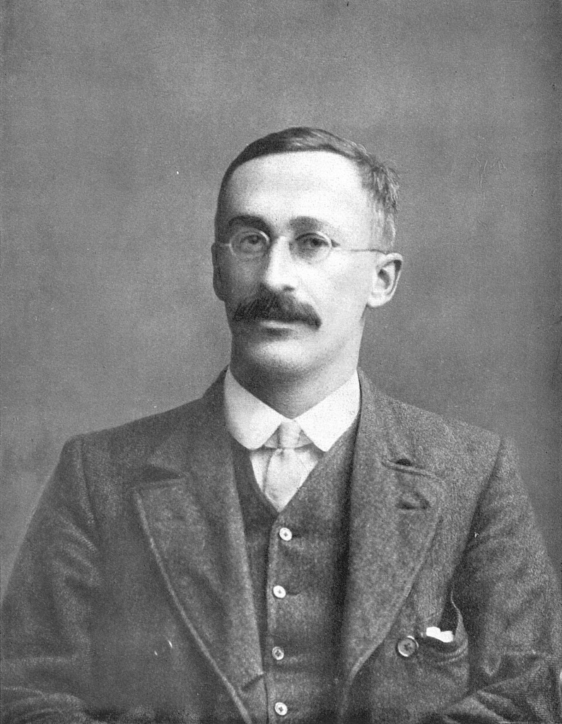

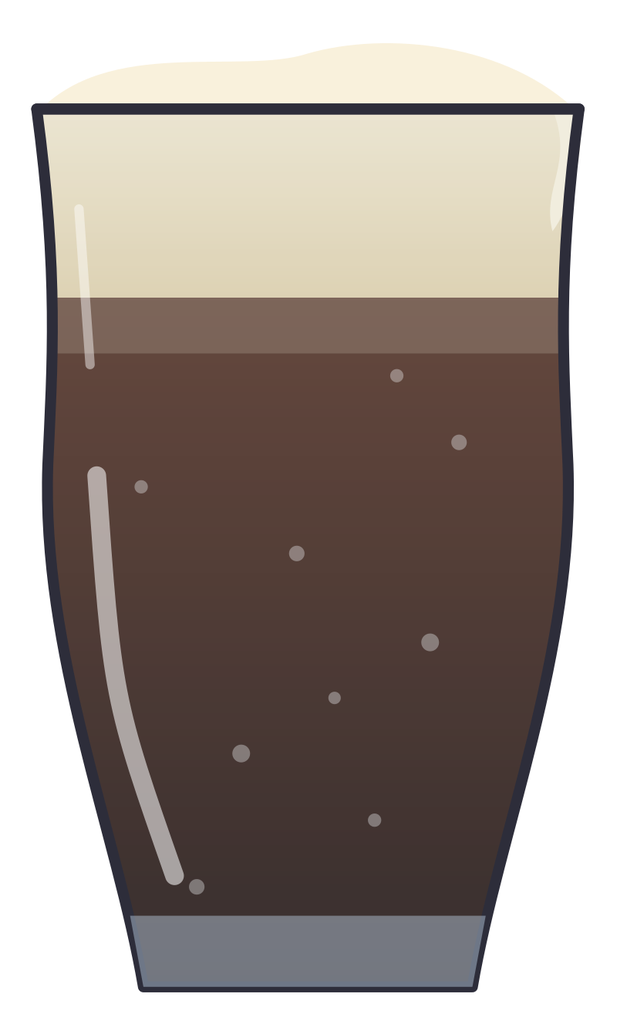

William Sealy Gosset, “Student” (1876–1937), Guinness brewery, Dublin, 1908. Photo: public domain (Wikimedia Commons).

## Quick review: Normal distribution

$$Y\sim N(\mu,\sigma^{2}), \ \ \ \ \ f_{Y}(y) = \frac{1}{\sqrt{2\pi{\color{#6A5ACD} \sigma}^{2}}}\ e^{-\frac{(y-{\color{#6A5ACD} \mu})^{2}}{2{\color{#6A5ACD} \sigma}^{2}}}$$

$$\mathbb{E}[Y] = \mu, \ \ \ \ \ \ \ \ \ \ \ \ \text{Var}[Y] = \sigma^{2},$$

$$Z = \frac{Y-\mu}{\sigma} \sim N(0,1), \ \ \ \ \ f_{Z}(z) = \frac{1}{\sqrt{2\pi}}\ e^{-\frac{z^{2}}{2}}.$$

Probability density function of a normal distribution:

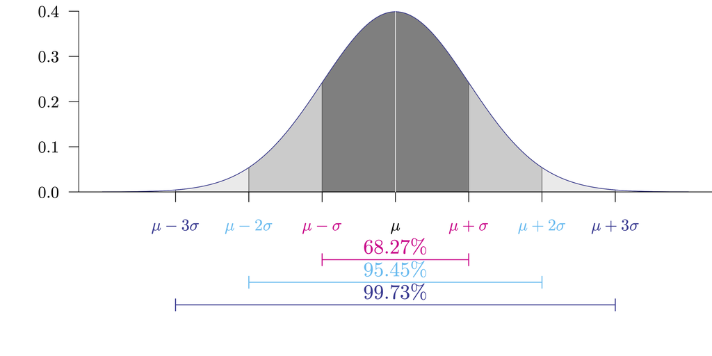

## Two-sample location tests

Goal: compare the means (or locations) of two independent samples. For example:

1. A volcanologist: mean SiO$_2$ content of magmas erupting through thin vs medium crust.
2. An ecologist: weight of salamanders in an old-growth forest vs a clear-cut area.
3. A limnologist: duration of lake ice cover before vs after 1950.
4. Does coffee raise blood pressure? ☕
5. Does the US economy grow faster under Democratic or Republican presidents? 🇺🇸 (see the beginning of the class)
6. Is a glass of red wine as good as an hour at the gym? 🍷

We will see three tests:

1. Student’s t-test: assumes equal variances.
2. Welch’s t-test: no equal-variance assumption.
3. Mann-Whitney-Wilcoxon test: based on ranks, robust to outliers.

## Student’s t-test

Model for groups A and B ($g = A, B$ and $i = 1, \ldots, n_g$), with the same variance in both groups:

$$X_{i(g)} = {\color{#eb078e}{\mu_{g}}} + \varepsilon_{i(g)}, \qquad \varepsilon_{i(g)} \overset{iid}{\sim} N(0,{\color{#eb078e}{\sigma^{2}}}).$$

Hypotheses (usually $\mu_0 = 0$) and test statistic under $H_0$ ($s_p$ = pooled standard deviation):

$$H_0: {\color{#6A5ACD}{\mu_A}} - {\color{#06bcf1}{\mu_B}} {\color{#eb078e}{=}} \mu_0 \quad \text{vs} \quad H_a: {\color{#6A5ACD}{\mu_A}} - {\color{#06bcf1}{\mu_B}} \ \big[ {\color{#eb078e}{>}} \text{ or } {\color{#eb078e}{<}} \text{ or } {\color{#eb078e}{\neq}} \big]\ \mu_0, \qquad T = \frac{(\overline{X}_{A}-\overline{X}_{B})-\mu_0}{s_{p}\sqrt{n_{A}^{-1}+n_{B}^{-1}}} \ {\overset{H_0}{\sim}} \ \text{Student}(n_{A}+n_{B}-2).$$

```python
from scipy import stats
stats.ttest_ind(a = ..., b = ..., alternative = ..., equal_var = True)
```

- Needs approximately normal data without outliers (for small or moderate $n$).
- The equal-variance assumption is hard to verify: we recommend avoiding this test in practice.

## Welch’s t-test

Same model and hypotheses as Student’s test, but each group has its own variance: $\varepsilon_{i(g)} \overset{iid}{\sim} N(0,{\color{#eb078e}{\sigma_g^{2}}})$.

Test statistic under $H_0$ ($df$ is computed from the data; the details are beyond the scope of this class):

$$T = \frac{(\overline{X}_{A}-\overline{X}_{B})-\mu_0}{\sqrt{s^2_A/n_{A} + s^2_B/n_{B}}} \ {\overset{H_0}{\sim}} \ \text{Student}(df).$$

```python
from scipy import stats
stats.ttest_ind(a = ..., b = ..., alternative = ..., equal_var = False)
```

- Needs approximately normal data without outliers (for small or moderate $n$).
- Does not require equal variances. If they happen to be equal it loses only a little power compared to Student’s test: our default choice.

## Thin vs medium crust — Graph

Do magmas erupting through thin and medium crust have the same mean SiO$_2$ content?

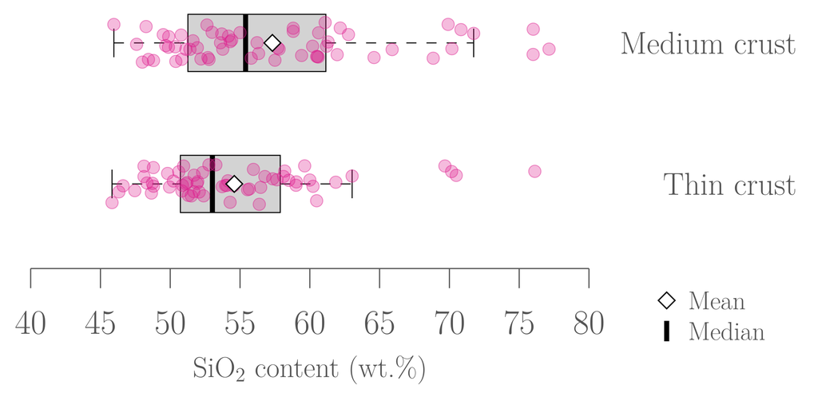

👋 Random subsample of $n = 60$ cells per group (fixed seed) from the 8498 cells of Farner & Lee (2017). The tests use the same subsample.

## Thin vs medium crust — Import the data

```python
# Import data
import pandas as pd
crust = pd.read_csv("https://raw.githubusercontent.com/ELSTE-Master/Data-Science/main/Data/arc_magmas_crust_sample.csv")

# Print the first rows of the dataset
print(crust.head(5))

# Variable of interest: SiO2 content (wt.%) for each crustal-thickness class
sio2_thin   = crust["sio2"][crust["crust_class"] == "thin"]
sio2_medium = crust["sio2"][crust["crust_class"] == "medium"]
```

```
        arc  latitude  longitude  crust_km crust_class   sio2
0    Aegean   36.3700    25.4600     27.99        thin  59.63
1  Aleutian   52.0000   178.1300     27.78        thin  51.20
2  Aleutian   52.8500   173.3100     27.99        thin  58.20
3  Aleutian   55.3409  -162.1291     33.09      medium  56.22
4  Aleutian   55.3929  -161.9471     34.07      medium  56.33
```

## Thin vs medium crust — Student’s t-test

```python
from scipy import stats

# Student's t-test (equal_var=True assumes equal variances)
t_stat, p_value = stats.ttest_ind(sio2_thin, sio2_medium, alternative="two-sided", equal_var=True)

print("t-statistic:", round(t_stat, 4))
print("p-value:", round(p_value, 4))
```

```
t-statistic: -2.1336
p-value: 0.0349
```

## Thin vs medium crust — Welch’s t-test

```python
from scipy import stats

# Welch's t-test (equal_var=False makes it Welch)
t_stat, p_value = stats.ttest_ind(sio2_thin, sio2_medium, alternative="two-sided", equal_var=False)

print("t-statistic:", round(t_stat, 4))
print("p-value:", round(p_value, 4))
```

```
t-statistic: -2.1336
p-value: 0.035
```

## What if one value were wrong?

The smallest medium-crust value is an Andean basalt with SiO$_2 = 46.0$ wt.%. Suppose it had been entered incorrectly: let us give it larger and larger values and redo Welch’s *t*-test. (Yes, a percentage cannot exceed 100: this is a thought experiment, a typing error can produce any number.)

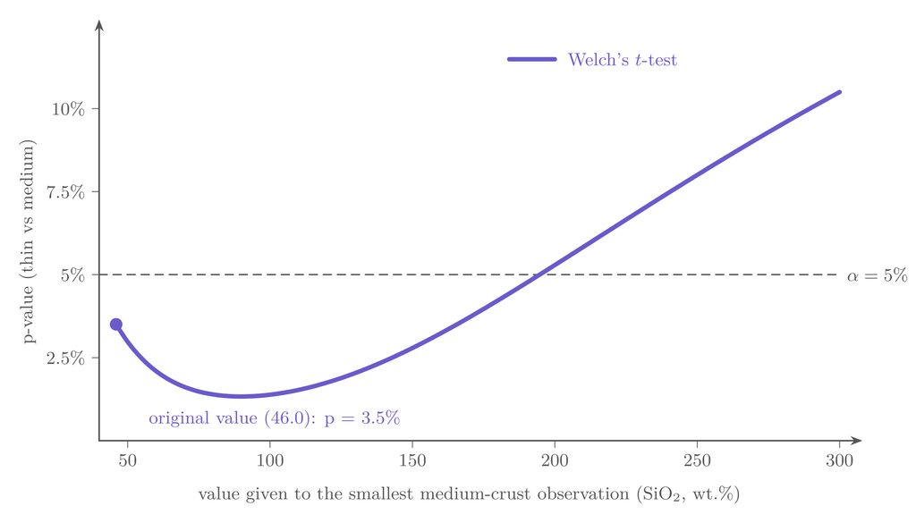

- At first the p-value decreases: the medium mean moves away from the thin mean.
- Then the inflated standard deviation makes the test lose significance: $5.3\%$ at 200, $16\%$ at 459.6.
- One wrong value can flip the conclusion: we need a test robust to such values.

## Mann-Whitney-Wilcoxon test

Model for groups A and B, without normality: $X_{i(g)} = {\color{#eb078e}{\theta_{g}}} + \varepsilon_{i(g)}$, $\varepsilon_{i(g)} \overset{iid}{\sim} (0,\sigma^{2})$, where $\theta_g$ is the population location of group $g$.

$$H_0: {\color{#6A5ACD}{\theta_A}} - {\color{#06bcf1}{\theta_B}} {\color{#eb078e}{=}} \theta_0 \quad \text{vs} \quad H_a: {\color{#6A5ACD}{\theta_A}} - {\color{#06bcf1}{\theta_B}} \ \big[ {\color{#eb078e}{>}} \text{ or } {\color{#eb078e}{<}} \text{ or } {\color{#eb078e}{\neq}} \big]\ \theta_0.$$

The test statistic uses the ranks of the observations in the pooled sample, not their values ($R_{i(g)}$ = global rank of the $i$-th observation of group $g$):

$$Z = \frac{\sum_{i=1}^{n_{B}}R_{i(B)}-n_{B}(n_{A}+n_{B}+1)/2}{\sqrt{n_{A}n_{B}(n_{A}+n_{B}+1)/12}}.$$

```python
from scipy import stats
stats.mannwhitneyu(x = ..., y = ..., alternative = ...)
```

- Robust: an extreme value only changes its rank, however large it is.
- To compare means ($\theta_g = \mu_g$) the distributions should be symmetric with equal variances; otherwise it compares locations (medians). Slightly less powerful than the $t$-tests when their assumptions hold.

## Thin vs medium crust — Wilcoxon

```python
from scipy import stats

# Wilcoxon rank-sum test (Mann–Whitney U)
w_stat, p_value = stats.mannwhitneyu(sio2_thin, sio2_medium, alternative="two-sided")

print("Wilcoxon statistic:", round(w_stat, 4))
print("p-value:", round(p_value, 4))
```

```
Wilcoxon statistic: 1422.0
p-value: 0.0475
```

Same conclusion as Welch’s *t*-test: $\text{p-value} = 4.75\% < 5\%$, we reject $H_0$.

## Robustness of the Wilcoxon test

Same experiment as before: the smallest medium-crust value is replaced by larger and larger values.

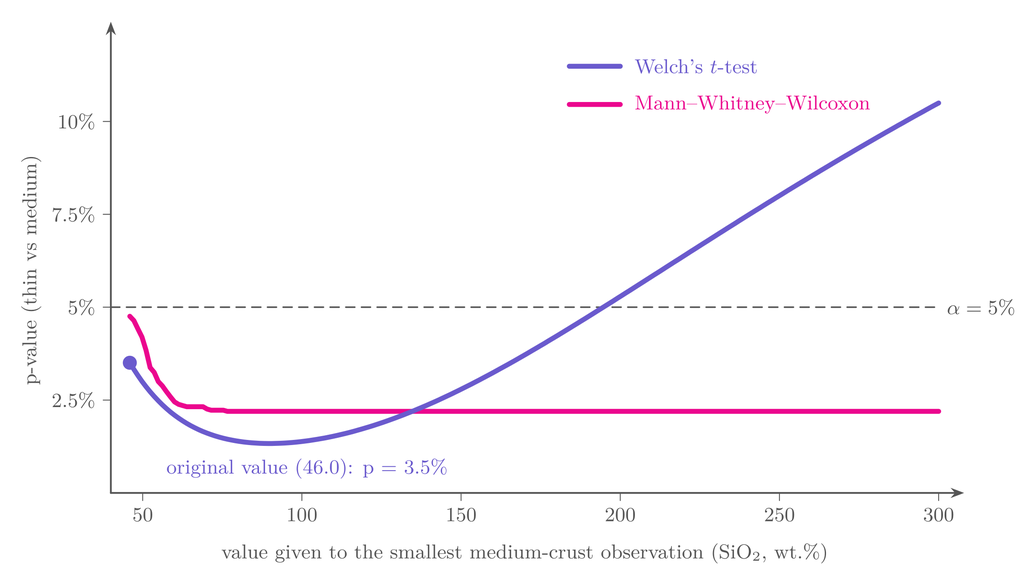

- Once the value is the largest of its group its rank no longer changes: the Wilcoxon p-value stays at $2.2\%$, whatever the value (even 459.6).
- The $t$-test p-value crosses $5\%$ around 200 and reaches $16\%$ for the decimal slip.
- Look at your data first: outliers or strong skewness are a good reason to prefer the Mann-Whitney-Wilcoxon test.

## Problems with multiple samples

Often we need to compare the means of more than 2 groups: for example the mean SiO$_2$ content of magmas erupting through thin, medium and thick crust. Following Farner & Lee (2017), our theory is that differentiation increases with crustal thickness:

$\color{#6A5ACD}{\mu_{\text{thin}}} < \color{#06bcf1}{\mu_{\text{medium}}} < \color{#8bb174}{\mu_{\text{thick}}}$

A possible approach: three one-sided tests, hoping to reject $H_0$ each time.

1. $H_0: \color{#6A5ACD}{\mu_{\text{thin}}} = \color{#06bcf1}{\mu_{\text{medium}}}$ vs $H_a: \color{#6A5ACD}{\mu_{\text{thin}}} < \color{#06bcf1}{\mu_{\text{medium}}}$
2. $H_0: \color{#06bcf1}{\mu_{\text{medium}}} = \color{#8bb174}{\mu_{\text{thick}}}$ vs $H_a: \color{#06bcf1}{\mu_{\text{medium}}} < \color{#8bb174}{\mu_{\text{thick}}}$
3. $H_0: \color{#6A5ACD}{\mu_{\text{thin}}} = \color{#8bb174}{\mu_{\text{thick}}}$ vs $H_a: \color{#6A5ACD}{\mu_{\text{thin}}} < \color{#8bb174}{\mu_{\text{thick}}}$

But is it OK to perform several tests on the same data? 🤔

## Is there a problem in doing many tests?

Are jelly beans causing acne? Maybe… but why only green ones? 🤨

## Are jelly beans causing acne?

[figure not shown]

Source: [xkcd](https://xkcd.com/882/)

## Maybe a specific color?

[figure not shown]

Source: [xkcd](https://xkcd.com/882/)

## Maybe a specific color?

[figure not shown]

Source: [xkcd](https://xkcd.com/882/)

## And finally…

👋 If you want to know more about this comic, have a look [here](https://www.explainxkcd.com/wiki/index.php/882:_Significant).

## Multiple testing can be dangerous!

- A p-value is random: it depends on the data.
- One test at $\alpha = 5\%$: a $5\%$ chance of a false alarm. $k$ tests: $k$ chances.
- For $k$ independent tests, all $H_0$ true:

$$\alpha_k = \Pr(\text{reject at least once}) = 1 - (1-\alpha)^k.$$

- Jelly beans: $k = 20$ colours, so $\alpha_{20} = 1 - 0.95^{20} \approx 64\%$. The “discovery” was expected, not lucky.
- ⚠️ Many tests, on the same or on different data, produce “significant” results even when nothing is there. Very common! 😟

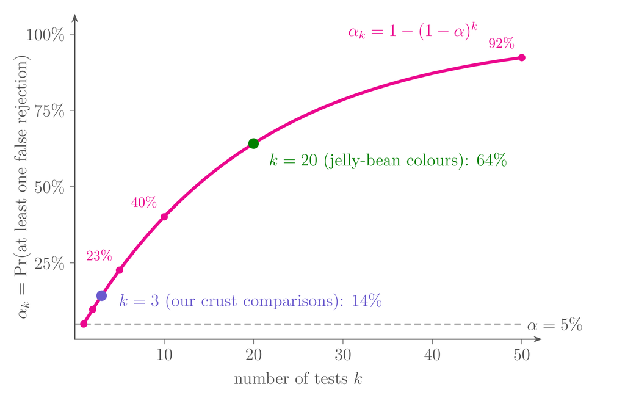

## Solution: a corrected level $\alpha_c$

Idea: we want the chance of at least one false rejection among the $k$ tests, $\alpha_k$, to be $\alpha$ (say $5\%$). So we run each test at a smaller level $\alpha_c$ instead of $\alpha$.

Boole’s inequality: the probability of a union is at most the sum of the probabilities, whatever the dependence between the events:

$$\alpha_k = \Pr(\text{reject test 1 OR} \ \ldots \ \text{OR reject test } k) \ {\color{#eb078e}{\leq}} \ \sum_{i=1}^k \Pr(\text{reject test } i) = k \, \alpha_c.$$

Imposing $k \, \alpha_c = \alpha$ gives the Bonferroni correction:

$$\color{#6A5ACD}{\alpha_c = \frac{\alpha}{k}}.$$

- Always valid: no assumption on the dependence between the tests, nor on how many $H_0$ are true.
- Our three crust comparisons: $\alpha_c = 5\%/3 \approx 1.67\%$. Jelly beans: $5\%/20 = 0.25\%$.

## Bonferroni, Dunn–Šidák and beyond

- Bonferroni is conservative: $\alpha_k$ ends up below $\alpha$, so each test loses power, more and more as $k$ grows.
- For independent tests, $\alpha_k$ is known exactly: $\alpha_k = 1 - (1-\alpha_c)^k$. Setting it to $\alpha$ gives the Dunn–Šidák correction:

$$\color{#6A5ACD}{\alpha_c = 1 - (1-\alpha)^{1/k}}.$$

| $k$ | 2 | 3 | 10 | 20 |
| --- | --- | --- | --- | --- |
| Bonferroni | $2.50\%$ | $1.67\%$ | $0.50\%$ | $0.25\%$ |
| Dunn–Šidák | $2.53\%$ | $1.70\%$ | $0.51\%$ | $0.26\%$ |

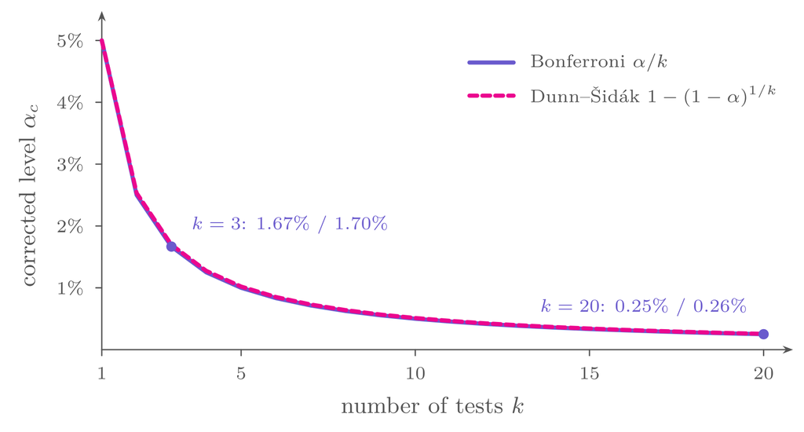

- Slightly less stringent, but exact only for independent tests. Pairwise comparisons sharing a group are dependent: Bonferroni is the safe choice.
- Thousands of tests (genomics): both corrections reject almost nothing. Methods controlling the False Discovery Rate are used instead (beyond this class).

## Multiple-sample location tests

Goal: compare the means (or locations) of $G \geq 2$ independent samples. For example, the mean SiO$_2$ content of magmas erupting through thin, medium and thick crust.

Standard procedure in two steps:

- Step 1: a multiple-sample location test of $H_0$: “all $G$ locations are equal”. If $H_0$ is not rejected, we stop here.
- Step 2: otherwise, we compare the groups pairwise with two-sample tests at a corrected level $\alpha_c$ (Bonferroni or Dunn–Šidák) to check our scientific hypothesis.

We will see three multiple-sample location tests:

1. Fisher’s one-way ANalysis Of VAriance (ANOVA): assumes equal variances.
2. Welch’s one-way ANOVA: no equal-variance assumption.
3. Kruskal-Wallis test: based on ranks, robust to outliers.

👋 Step 1 is a single test, whatever the number of groups: the multiple-testing problem (and $\alpha_c$) only appears at Step 2.

## Fisher’s one-way ANOVA

Model for $G$ groups ($g = 1, \ldots, G$ and $i = 1, \ldots, n_g$), with the same variance in all groups:

$$X_{i(g)} = {\color{#eb078e}{\mu_{g}}} + \varepsilon_{i(g)}, \qquad \varepsilon_{i(g)} \overset{iid}{\sim} N(0,{\color{#eb078e}{\sigma^{2}}}).$$

Hypotheses:

$$H_0: {\color{#6A5ACD}{\mu_1}} {\color{#eb078e}{=}} {\color{#06bcf1}{\mu_2}} {\color{#eb078e}{=}} \ldots {\color{#eb078e}{=}} {\color{#8bb174}{\mu_G}} \quad \text{vs} \quad H_a: \mu_i {\color{#eb078e}{\neq}} \mu_j \ \text{ for at least one pair } (i,j).$$

Test statistic under $H_0$: the variability between the group means divided by the variability within the groups, where $N = \sum_g n_g$ and $\overline{X}$ is the mean of all $N$ observations. Means far apart compared to the noise give a large $F$, i.e. a small p-value:

$$F = \frac{\frac{1}{G-1}\sum_{g=1}^G n_g \left(\overline{X}_g - \overline{X}\right)^2}{\frac{1}{N-G}\sum_{g=1}^G (n_g - 1)\, s_g^2} \ {\overset{H_0}{\sim}} \ \text{Fisher}(G-1,\, N-G).$$

```python
from scipy import stats
stats.f_oneway(group_1, group_2, group_3)   # no "alternative": Ha is always "at least one pair differs"
```

- Needs approximately normal data without outliers (for small or moderate $n_g$). For $G = 2$ it is Student’s test ($F = T^2$).
- The equal-variance assumption is hard to verify: we recommend avoiding this test in practice.

## Welch’s one-way ANOVA

Same model and hypotheses as Fisher’s ANOVA, but each group has its own variance: $\varepsilon_{i(g)} \overset{iid}{\sim} N(0,{\color{#eb078e}{\sigma_g^{2}}})$.

Test statistic under $H_0$: each group mean is weighted by its precision $w_g = n_g / s_g^2$ (the correction in the denominator and $\Delta$ are computed from the data; the details are beyond the scope of this class):

$$F^* = \frac{\frac{1}{G-1}\sum_{g=1}^G w_g \left(\overline{X}_g - \overline{X}^*\right)^2}{1 + \frac{2(G-2)}{3\Delta}} \ {\overset{H_0}{\sim}} \ \text{Fisher}(G-1,\, \Delta), \qquad \overline{X}^* = \frac{\sum_{g=1}^G w_g \overline{X}_g}{\sum_{g=1}^G w_g}.$$

For the curious: $\Delta = \Big[\frac{3}{G^2-1} \sum_{g=1}^G \frac{1}{n_g-1} \big(1-\frac{w_g}{\sum_{h=1}^G w_h}\big)^2\Big]^{-1}$. For $G = 2$ it is Welch’s $t$-test ($F^* = T^2$ and $\Delta = df$).

```python
from statsmodels.stats.oneway import anova_oneway
anova_oneway(data = ..., groups = ..., use_var = "unequal", welch_correction = True)
```

- Needs approximately normal data without outliers (for small or moderate $n_g$).
- Does not require equal variances. If they happen to be equal it loses only a little power compared to Fisher’s ANOVA: our default choice.

## Kruskal-Wallis test

Model for $G$ groups, without normality: $X_{i(g)} = {\color{#eb078e}{\theta_{g}}} + \varepsilon_{i(g)}$, $\varepsilon_{i(g)} \overset{iid}{\sim} (0,\sigma^{2})$, where $\theta_g$ is the population location of group $g$.

$$H_0: {\color{#6A5ACD}{\theta_1}} {\color{#eb078e}{=}} {\color{#06bcf1}{\theta_2}} {\color{#eb078e}{=}} \ldots {\color{#eb078e}{=}} {\color{#8bb174}{\theta_G}} \quad \text{vs} \quad H_a: \theta_i {\color{#eb078e}{\neq}} \theta_j \ \text{ for at least one pair } (i,j).$$

The test statistic applies the ANOVA idea to the ranks of the pooled sample, not to the values: it measures how far the mean rank of each group, $\overline{R}_g$, is from the mean of all ranks, $(N+1)/2$:

$$H = \frac{12}{N(N+1)} \sum_{g=1}^G n_g \left(\overline{R}_g - \frac{N+1}{2}\right)^2 \ {\overset{H_0}{\sim}} \ \chi^2(G-1).$$

With ties, $H$ is divided by $1 - \sum_{v=1}^V (t_v^3 - t_v)/(N^3 - N)$, where $t_v$ is the number of observations sharing the $v$-th distinct value.

```python
from scipy import stats
stats.kruskal(group_1, group_2, group_3)
```

- Robust: an extreme value only changes its rank, however large it is.
- To compare means ($\theta_g = \mu_g$) the distributions should be symmetric with equal variances; otherwise it compares locations (medians). Slightly less powerful than the ANOVAs when their assumptions hold.

## Thin, medium, thick crust — Graph

Is the mean SiO$_2$ content of arc magmas the same for thin, medium and thick crust? Our theory (Farner & Lee, 2017): $\mu_{\text{thin}}$ $<$ $\mu_{\text{medium}}$ $<$ $\mu_{\text{thick}}$.

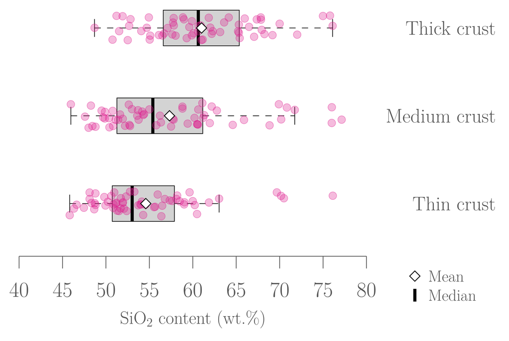

👋 Random subsample of $n = 60$ cells per group (fixed seed) from the 8498 cells of Farner & Lee (2017). The tests use the same subsample.

## Thin, medium, thick crust — Import

```python
# Import data
import pandas as pd
crust = pd.read_csv("https://raw.githubusercontent.com/ELSTE-Master/Data-Science/main/Data/arc_magmas_crust_sample.csv")

# Variables of interest: SiO2 content (wt.%) for each crustal-thickness class
sio2_thin   = crust["sio2"][crust["crust_class"] == "thin"]
sio2_medium = crust["sio2"][crust["crust_class"] == "medium"]
sio2_thick  = crust["sio2"][crust["crust_class"] == "thick"]

# Summary by class
summary = crust.groupby("crust_class")["sio2"].agg(["count", "mean", "std", "median"])
print(summary.loc[["thin", "medium", "thick"]].round(2))
```

```
             count   mean   std  median
crust_class
thin            60  54.59  6.22   53.02
medium          60  57.32  7.72   55.40
thick           60  61.01  6.39   60.64
```

## Thin, medium, thick crust — Step 1

```python
from scipy import stats
from statsmodels.stats.oneway import anova_oneway

# Fisher's one-way ANOVA
F_stat, p_fisher = stats.f_oneway(sio2_thin, sio2_medium, sio2_thick)
print("Fisher's ANOVA:  F =", round(F_stat, 3), " p-value =", f"{p_fisher:.1e}")

# Welch's one-way ANOVA
res = anova_oneway(crust["sio2"], groups=crust["crust_class"], use_var="unequal", welch_correction=True)
print("Welch's ANOVA:   F =", round(res.statistic, 3), " p-value =", f"{res.pvalue:.1e}")

# Kruskal-Wallis test
H_stat, p_kw = stats.kruskal(sio2_thin, sio2_medium, sio2_thick)
print("Kruskal-Wallis:  H =", round(H_stat, 3), " p-value =", f"{p_kw:.1e}")
```

```
Fisher's ANOVA:  F = 13.427  p-value = 3.7e-06
Welch's ANOVA:   F = 15.519  p-value = 1.1e-06
Kruskal-Wallis:  H = 29.124  p-value = 4.7e-07
```

All three p-values are far below $5\%$: we reject $H_0$, the mean SiO$_2$ content is not the same in the three classes. On to Step 2.

## Thin, medium, thick crust — Step 2

Three one-sided Welch $t$-tests (Tests 1 to 3), each at the Bonferroni level $\alpha_c = 0.05/3 \approx 1.67\%$ (Dunn–Šidák would give $1.70\%$).

```python
from scipy import stats

alpha_c = 0.05 / 3                                      # Bonferroni correction, 3 tests

# Test 1:  H0: mu_thin = mu_medium    vs  Ha: mu_thin < mu_medium
p_1 = stats.ttest_ind(sio2_thin, sio2_medium, alternative="less", equal_var=False).pvalue
# Test 2:  H0: mu_medium = mu_thick   vs  Ha: mu_medium < mu_thick
p_2 = stats.ttest_ind(sio2_medium, sio2_thick, alternative="less", equal_var=False).pvalue
# Test 3:  H0: mu_thin = mu_thick     vs  Ha: mu_thin < mu_thick
p_3 = stats.ttest_ind(sio2_thin, sio2_thick, alternative="less", equal_var=False).pvalue

for name, p in [("Test 1 (thin < medium) ", p_1), ("Test 2 (medium < thick)", p_2), ("Test 3 (thin < thick)  ", p_3)]:
    print(name, " p-value =", f"{p:.1e}", " -> reject H0" if p < alpha_c else " -> do not reject H0")
```

```
Test 1 (thin < medium)   p-value = 1.8e-02  -> do not reject H0
Test 2 (medium < thick)  p-value = 2.6e-03  -> reject H0
Test 3 (thin < thick)    p-value = 7.9e-08  -> reject H0
```

## Thin, medium, thick crust — Conclusion

| Test | $H_a$ | p-value | Decision at $\alpha_c = 1.67\%$ |
| --- | --- | --- | --- |
| 1 | $\color{#6A5ACD}{\mu_{\text{thin}}} < \color{#06bcf1}{\mu_{\text{medium}}}$ | $1.75\%$ | not rejected |
| 2 | $\color{#06bcf1}{\mu_{\text{medium}}} < \color{#8bb174}{\mu_{\text{thick}}}$ | $0.26\%$ | reject $H_0$ ✅ |
| 3 | $\color{#6A5ACD}{\mu_{\text{thin}}} < \color{#8bb174}{\mu_{\text{thick}}}$ | $8 \times 10^{-8}$ | reject $H_0$ ✅ |

- Magmas erupting through thick crust have a higher mean SiO$_2$ content than those erupting through medium or thin crust (Tests 2 and 3).
- Thin vs medium: p-value $= 1.75\%$, just above $\alpha_c$. ⚠️ Alone at $\alpha = 5\%$ this test rejects $H_0$: the correction for multiple testing changes the conclusion. And not rejecting does not prove that $\mu_{\text{thin}}$ $=$ $\mu_{\text{medium}}$.
- The data support the thick-crust part of our theory $\mu_{\text{thin}}$ $<$ $\mu_{\text{medium}}$ $<$ $\mu_{\text{thick}}$, but not (yet) the thin-to-medium step.
- With all 8498 cells: mean SiO$_2$ of $57.1$, $56.9$ and $61.2$ wt.%, p-values $< 10^{-88}$ for Tests 2 and 3 but $88\%$ for Test 1: the thin-to-medium step is not supported. Differentiation seems only strongly enhanced once the crust is thick.